# Descriptive Statistics and Data Visualization in R: Dispersion and Spread

2024

## Introduction to Variability

- **Variability** refers to how spread out or closely clustered a set of data is.
- Common measures include the **range**, **variance**, and **standard deviation**.

## Sample Range

- The **sample range** is the simplest measure of variability.
- It is calculated as the difference between the maximum and minimum values in a set of observations.
- For a sample \(\boldsymbol{x}\), the range is:

\[ \text{Range} = \text{Max}(\boldsymbol{x}) - \text{Min}(\boldsymbol{x}) \].

## Sample Range Example

- Consider a sample \(\boldsymbol{x} = 9, 15, 24, 3, 18\)
- The sample range is: \[ \text{Range} = 24 - 3 = 21 \]

## The `range` function in R

```r
x <- c(9, 15, 24, 3, 18)
range(x)
```

```
## [1]  3 24
```

## Sample Variance

- The ** Sample Variance** quantifies the average squared deviations from the mean of a set of observations.
- It is denoted by \(s^2\).

\[ \begin{align} s^2 &= \frac{1}{n-1}( (x_1 - \overline{\boldsymbol{x}})^2 + (x_2 - \overline{\boldsymbol{x}})^2 + \ldots + (x_n - \overline{\boldsymbol{x}})^2 )\\ &= \frac{1}{n-1} \sum_{i=1}^{n} (x_i - \overline{\boldsymbol{x}})^2 \end{align} \]

## Sample Variance Example

- Given the same sample \(\boldsymbol{x} = 9, 15, 24, 3, 18\)

## The `var` function in R

```r
x <- c(9, 15, 24, 3, 18)
var(x)
```

```
## [1] 65.7
```

## Sample Standard Deviation

- The sample **Standard Deviation** is the square root of the sample variance.
- It measures the dispersion of data points from their mean.
- Formula: \(s = \sqrt{s^2}\).

## Sample Standard Deviation Example

- Using the same sample \(\boldsymbol{x} = 9, 15, 24, 3, 18\), the sample standard deviation is:

## The `sd` function in R

```r
sd(x)
```

```
## [1] 8.105554
```

## Visualizing Variability: Histogram

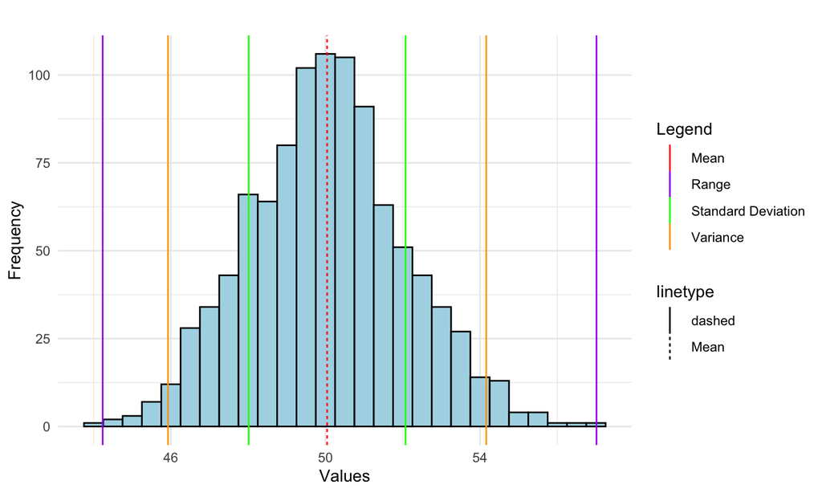

## Sample Skewness

- **Sample Skewness** measures the asymmetry of the distribution of data.
- It provides insights into the shape of the data

## Sample Skewness Example

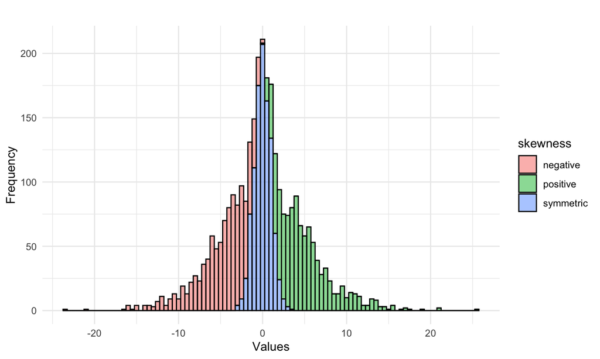

## Sample Kurtosis

- **Sample Kurtosis** measures the “tailedness” of the distribution.
- It provides insights into the shape of the data

## Sample Kurtosis Example

- Leptokurtic: Distributions with positive excess kurtosis (sharper peak and fatter tails than the normal distribution). Example: T-distribution with low degrees of freedom.
- Platykurtic: Distributions with negative excess kurtosis (flatter peak and thinner tails than the normal distribution). Example: Uniform distribution.
- Mesokurtic: Distributions with zero excess kurtosis, similar to the normal distribution. The standard normal distribution itself is an example.

## Sample Kurtosis Example Visual

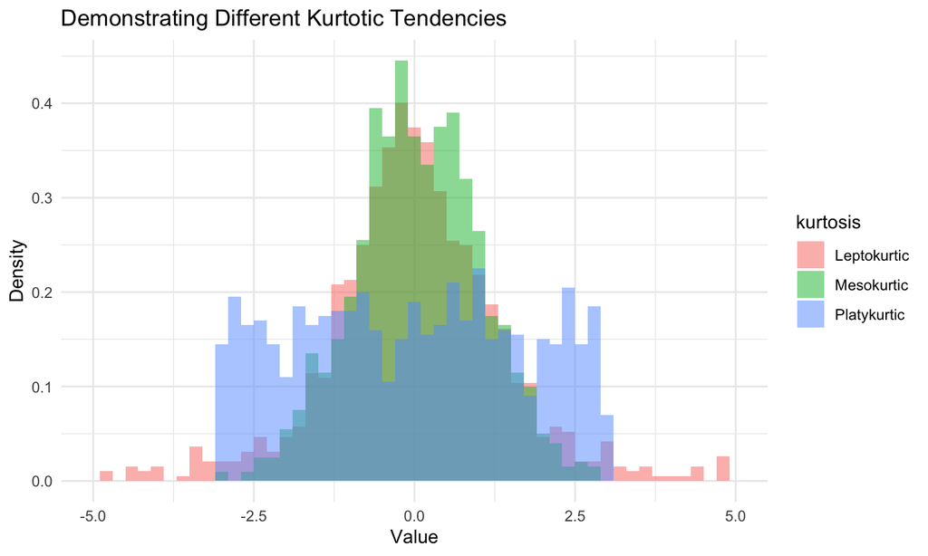

## Question

Consider the following histogram of a sample of data:

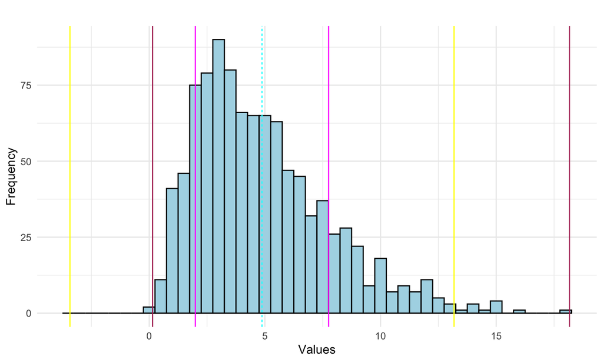

Which line shows the sd, var, range, and mean of the sample?

**Click here for the answer**

**Correct Answer:** The cyan line shows the mean, the magenta line shows the standard deviation, the yellow line shows the variance, and the maroon lines show the range.

## Question

Consider the following histogram of a sample of data:

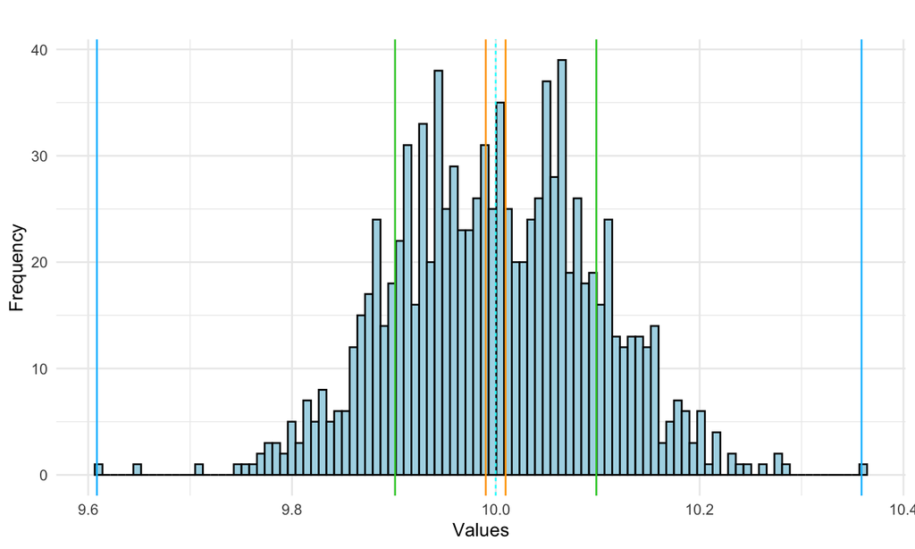

Which line shows the sd, var, range, and mean of the sample?

**Click here for the answer**

**Correct Answer:** The cyan line shows the mean, the limegreen line shows the standard deviation, the orange line shows the variance, and the deepskyblue lines show the range.